# RelatorioRedesEventos

2024-12-16

# 1 A fazer no relatório

- Aumentar tamanho das imagens
- Incluir imagem só com a legenda, para adicionar futuramente em editores de imagem
- Incluir mais labels em alguns dos graficos
- Incluir comparativo dos dados de topografia de cada rede
- Incluir redes em janelas 4 anos

# 2 Preparo dos dados

## 2.1 Versão do banco

Relatório mais recente: “2024-12-16”

**Versão da planilha deleg**: 2023-12-20

**Versão da planilha orgs**: 2023-12-20

**Versão da planilha class**: 2022-06-29

**Versão da planilha eventos**: 2023-12-14

**Versão da planilha individuos**: 2023-12-21

```r
# We can now see all vertex attributes:
# vertex.attributes(eventNet)
summary(eventNet)
```

```
## IGRAPH f5789d2 UNW- 311 3759 --
## + attr: name (v/c), confid (v/c), conference (v/c), tema (v/c), ano
## | (v/c), weight (e/n)
```

# 3 EVENTS PROJECTED NETWORK

Assortativity with respect to a specific feature is the Pearson correlation between the features of connected non-identical node pairs. Per this definition it is a number from -1 to 1. If this is positive, then connected nodes tend to have positively correlated features. If assortativity is negative, the connected node pairs tend to have negatively correlated features. This definition makes sense only for features that can be rank ordered (e.g. number of links, height, age, wealth, etc) But for features that are not rank ordered (e.g. color), one might be interested in the Modularity or how nodes in a graph tend to connect to other nodes with the same module. Again using a non-directed graph as an example, modularity is a number we can calculate by comparing the number of links observed within a module/feature vs the average number of links within the same feature if the graph was randomly generated. Para cálculo da modularidade por clusters, foi usado o algoritmo multinível de otimização de modularidade de Blondel et al. (2008) para detecção de comunidades (função igraph::cluster_louvain). Foram usados os parâmetros padrão da função, considerando o peso das arestas (no caso, o nº de co-participantes).

## 3.1 Rede estática (1970-2018)

```r
full_eventNet <- yearfilter_net(eventNet, 1970, 2018)
```

### 3.1.1 Centralidade dos eventos/conferências

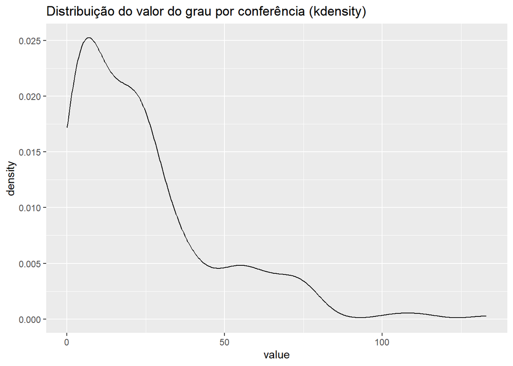

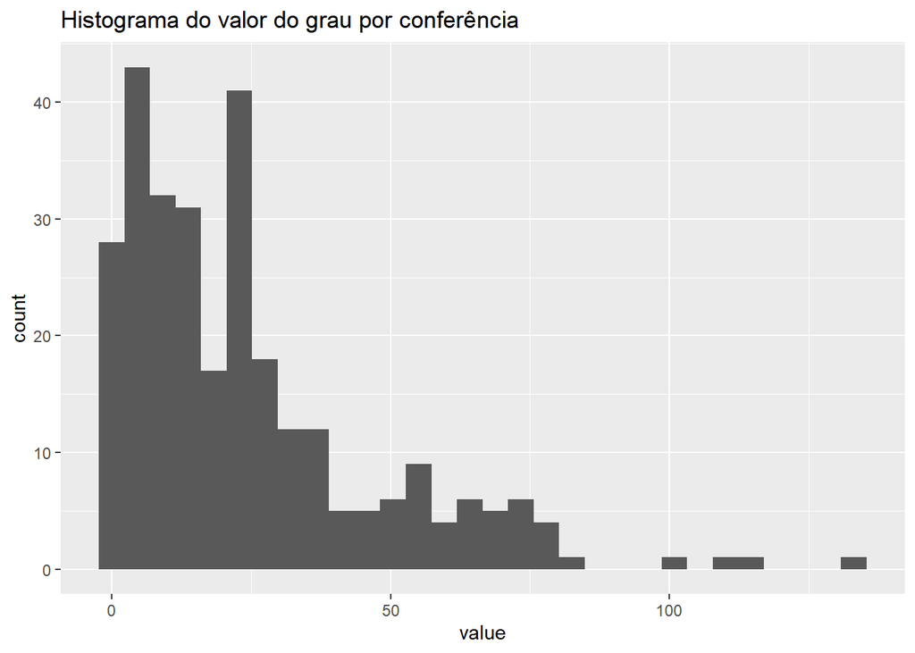

Estatísticas descritivas de grau - Rede Eventos (1970-2018)

| mean | sd | coef_var | median |
| --- | --- | --- | --- |
| 24.20069 | 22.75583 | 0.9402965 | 18 |

Abaixo, as conferências com maior centralidade (grau simples)

Grau simples por conferências, top 30

| id | label | conference | tema | deg | deg_overavg | deg_overmedian |
| --- | --- | --- | --- | --- | --- | --- |
| 421 | UNCSD,Conf | UNCSD | Grandes conferências ONU | 133 | 5.495711 | 7.388889 |
| 411 | UNCED,Conf | UNCED | Grandes conferências ONU | 114 | 4.710609 | 6.333333 |
| 587 | WSSD,Conf | WSSD | Grandes conferências ONU | 108 | 4.462682 | 6.000000 |
| 539 | UNFCCC,COP15 | UNFCCC | Clima | 102 | 4.214755 | 5.666667 |
| 534 | UNFCCC,COP10 | UNFCCC | Clima | 82 | 3.388333 | 4.555556 |
| 537 | UNFCCC,COP13 | UNFCCC | Clima | 78 | 3.223048 | 4.333333 |
| 544 | UNFCCC,COP20 | UNFCCC | Clima | 78 | 3.223048 | 4.333333 |
| 536 | UNFCCC,COP12 | UNFCCC | Clima | 76 | 3.140406 | 4.222222 |
| 547 | UNFCCC,COP23 | UNFCCC | Clima | 76 | 3.140406 | 4.222222 |
| 545 | UNFCCC,COP21 | UNFCCC | Clima | 75 | 3.099085 | 4.166667 |
| 34 | CBD,COP13 | Convention on Biological Diversity | Biodiversidade - CBD | 74 | 3.057764 | 4.111111 |
| 540 | UNFCCC,COP16 | UNFCCC | Clima | 74 | 3.057764 | 4.111111 |
| 542 | UNFCCC,COP18 | UNFCCC | Clima | 73 | 3.016443 | 4.055556 |
| 546 | UNFCCC,COP22 | UNFCCC | Clima | 73 | 3.016443 | 4.055556 |
| 541 | UNFCCC,COP17 | UNFCCC | Clima | 72 | 2.975122 | 4.000000 |
| 31 | CBD,COP10 | Convention on Biological Diversity | Biodiversidade - CBD | 71 | 2.933800 | 3.944444 |
| 533 | UNFCCC,COP09 | UNFCCC | Clima | 71 | 2.933800 | 3.944444 |
| 535 | UNFCCC,COP11 | UNFCCC | Clima | 68 | 2.809837 | 3.777778 |
| 30 | CBD,COP09 | Convention on Biological Diversity | Biodiversidade - CBD | 67 | 2.768516 | 3.722222 |
| 543 | UNFCCC,COP19 | UNFCCC | Clima | 67 | 2.768516 | 3.722222 |
| 529 | UNFCCC,COP06 | UNFCCC | Clima | 66 | 2.727195 | 3.666667 |
| 157 | ICCD,COP03 | UN Convention to Combat Desertification | Desertificação | 65 | 2.685874 | 3.611111 |
| 32 | CBD,COP11 | Convention on Biological Diversity | Biodiversidade - CBD | 64 | 2.644553 | 3.555556 |
| 552 | UNFCCC,INC02 | UNFCCC | Clima | 64 | 2.644553 | 3.555556 |
| 590 | WSSD,PrepCom, 3 | WSSD | Grandes conferências ONU | 64 | 2.644553 | 3.555556 |
| 526 | UNFCCC,COP03 | UNFCCC | Clima | 62 | 2.561910 | 3.444444 |
| 532 | UNFCCC,COP08 | UNFCCC | Clima | 60 | 2.479268 | 3.333333 |
| 527 | UNFCCC,COP04 | UNFCCC | Clima | 59 | 2.437947 | 3.277778 |
| 538 | UNFCCC,COP14 | UNFCCC | Clima | 59 | 2.437947 | 3.277778 |
| 548 | UNFCCC,COP24 | UNFCCC | Clima | 59 | 2.437947 | 3.277778 |

### 3.1.2 Dados de topologia da rede

Estatísticas de topologia da rede

| Statistic | Value | Network | YearBegin | YearEnd |
| --- | --- | --- | --- | --- |
| NVertices | 289.0000000 | EventosTotal | 1970 | 2018 |
| NArestas | 3497.0000000 | EventosTotal | 1970 | 2018 |
| ArestasporVertice | 12.1003460 | EventosTotal | 1970 | 2018 |
| GrauMed | 24.2006920 | EventosTotal | 1970 | 2018 |
| GrauMed_weighted | 73.4532872 | EventosTotal | 1970 | 2018 |
| PesoMedioAresta | 3.0351730 | EventosTotal | 1970 | 2018 |
| Average_path_length | 2.5021249 | EventosTotal | 1970 | 2018 |
| Average_path_length_weighted | 2.6982591 | EventosTotal | 1970 | 2018 |
| Diameter | 8.0000000 | EventosTotal | 1970 | 2018 |
| Diameter_weighted | 11.0000000 | EventosTotal | 1970 | 2018 |
| Densidade | 0.0840302 | EventosTotal | 1970 | 2018 |
| Transitivity | 0.4699422 | EventosTotal | 1970 | 2018 |
| Transitivity_weighted_mean | 0.6582526 | EventosTotal | 1970 | 2018 |
| Average_clustering_coef | 0.6096176 | EventosTotal | 1970 | 2018 |
| N_componentes_isolados | 10.0000000 | EventosTotal | 1970 | 2018 |
| Cobertura_maiorcomp | 0.9688581 | EventosTotal | 1970 | 2018 |
| N_clustersLouvain | 17.0000000 | EventosTotal | 1970 | 2018 |
| Modularidade_clustersLouvain | 0.3170864 | EventosTotal | 1970 | 2018 |
| Modularidade_temas | 0.2594532 | EventosTotal | 1970 | 2018 |
| Modularidade_conference | 0.2083641 | EventosTotal | 1970 | 2018 |
| Assortativity_Ano | 0.5381472 | EventosTotal | 1970 | 2018 |

### 3.1.3 Visualização

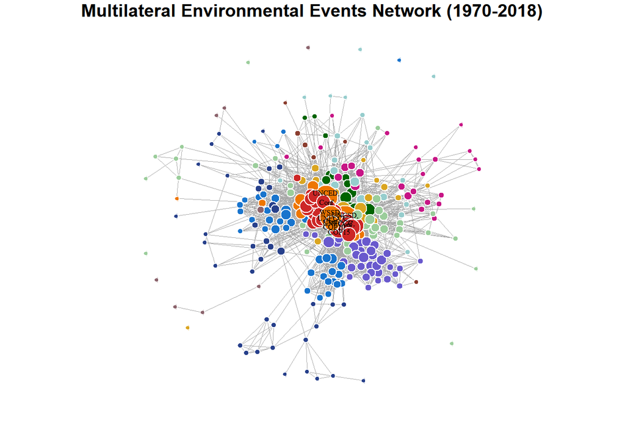

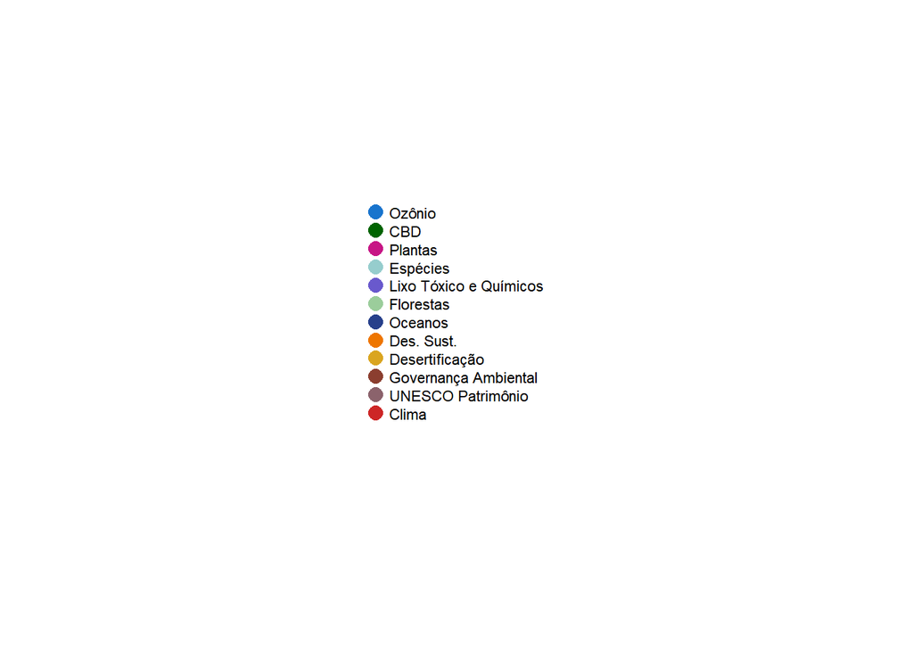

## 3.2 Rede estática simplificada a nível de conferência (1970-2018)

Para simplificar a rede e discernir mais claramente as estruturas, combinamos os vértices de eventos referentes às mesmas conferências.

```r
# Generating a simplified event network ----

# Collapse all nodes by conference to simplify full_eventNet

# To do this, we need a mapping of existing conferences
conf_list <- unique(V(full_eventNet)$conference)
# We can then collapse the nodes with contract
simple_eventNet <- contract(
  full_eventNet,
  mapping = as.numeric(
    plyr::mapvalues(V(full_eventNet)$conference, from = conf_list,
                    to = 1:length(conf_list))
  ),
  vertex.attr.comb=list(#methods for combining attributes
    weight="sum", "first")) #sum weights, keep first of others
# contract generates a multilayer network, which we then simplify
simple_eventNet <- simplify(simple_eventNet) # this also sums weight of edges
```

### 3.2.1 Visualização

Na visualização, usamos o grau simples (sem peso, só degree centrality) como base para o tamanho dos nós. Interesse é mais identificar as principais agendas (não necessariamente ‘quais conectam as demais’ etc). Grau com peso distorce demais devido ao peso da UNFCCC. Algoritmo para layout foi o force-directed GEM.

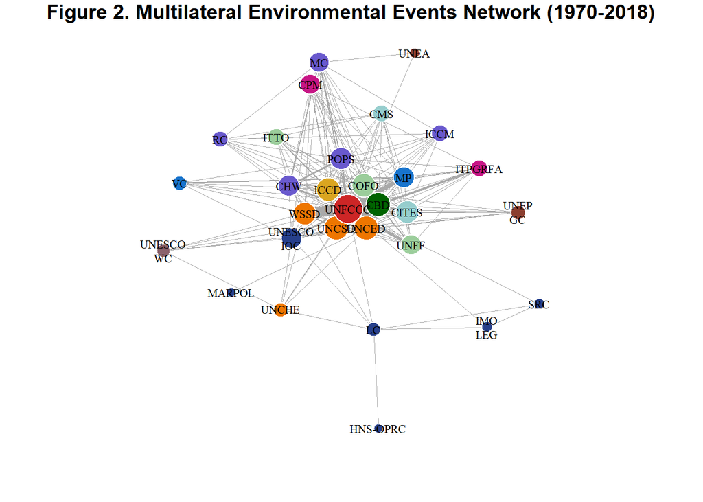

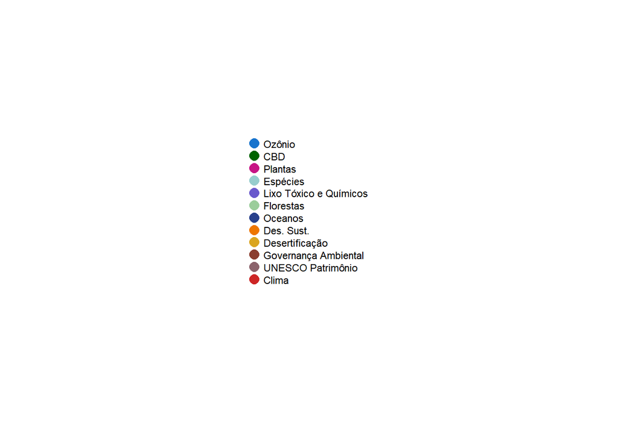

### 3.2.2 Centralidade dos eventos/conferências

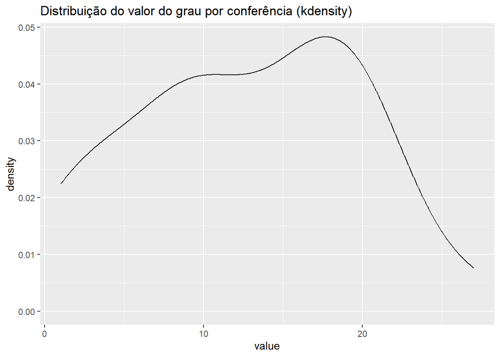

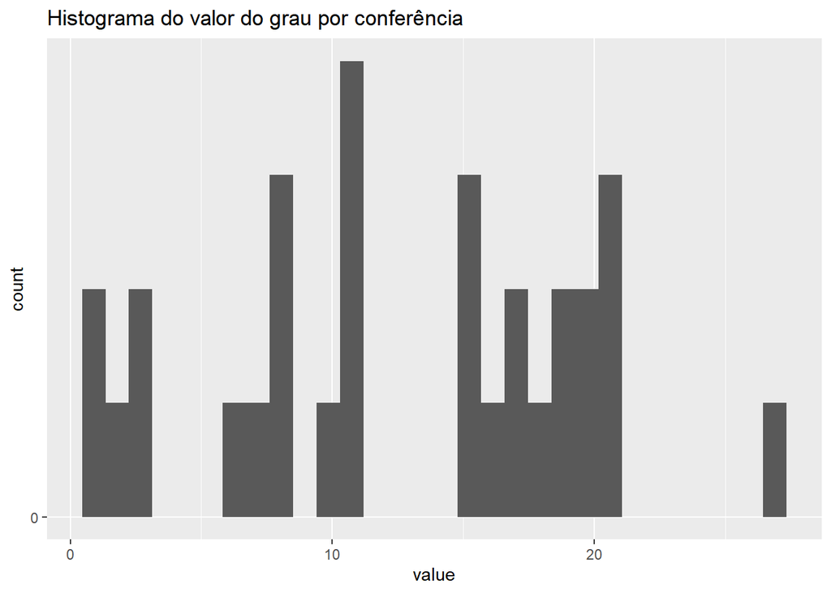

Estatísticas descritivas de grau - Rede simplificada por conf (1970-2018)

| mean | sd | coef_var | median |
| --- | --- | --- | --- |
| 12.73333 | 7.016893 | 0.5510649 | 13 |

Abaixo, as conferências com maior centralidade (grau simples)

Grau simples por conferências, top 30

| id | label | conference | tema | deg | deg_overavg | deg_overmedian |
| --- | --- | --- | --- | --- | --- | --- |
| 524 | UNFCCC | UNFCCC | Clima | 27 | 2.1204188 | 2.0769231 |
| 15 | CBD | Convention on Biological Diversity | Biodiversidade - CBD | 21 | 1.6492147 | 1.6153846 |
| 411 | UNCED | UNCED | Grandes conferências ONU | 21 | 1.6492147 | 1.6153846 |
| 421 | UNCSD | UNCSD | Grandes conferências ONU | 21 | 1.6492147 | 1.6153846 |
| 108 | COFO | FAO Committee on Forestry | Florestas | 20 | 1.5706806 | 1.5384615 |
| 156 | ICCD | UN Convention to Combat Desertification | Desertificação | 20 | 1.5706806 | 1.5384615 |
| 77 | CITES | Convention on International Trade in Endangered Species of Wild Fauna and Flora | Biodiversidade - Espécies | 19 | 1.4921466 | 1.4615385 |
| 587 | WSSD | WSSD | Grandes conferências ONU | 19 | 1.4921466 | 1.4615385 |
| 361 | POPS | Stockholm Convention on Persistent Organic Pollutants | Lixo tóxico e químicos | 18 | 1.4136126 | 1.3846154 |
| 6 | MP | Montreal Protocol on Substances that Deplete the Ozone Layer | Ozônio | 17 | 1.3350785 | 1.3076923 |
| 66 | CHW | Basel Convention on the Control of Transboundary Movements of Hazardous Wastes and their Disposal | Lixo tóxico e químicos | 17 | 1.3350785 | 1.3076923 |
| 476 | UNESCOIOC | UNESCO IOC | Oceano | 16 | 1.2565445 | 1.2307692 |
| 132 | CPM | International Plant Protection Convention | Biodiversidade - Plantas | 15 | 1.1780105 | 1.1538462 |
| 310 | MC | Minamata Convention on Mercury | Lixo tóxico e químicos | 15 | 1.1780105 | 1.1538462 |
| 566 | UNFF | United Nations Forum on Forests | Florestas | 15 | 1.1780105 | 1.1538462 |
| 52 | ITPGRFA | International Treaty on Plant Genetic Resources for Food and Agriculture | Biodiversidade - Plantas | 11 | 0.8638743 | 0.8461538 |
| 95 | CMS | Convention on Migratory Species | Biodiversidade - Espécies | 11 | 0.8638743 | 0.8461538 |
| 180 | ICCM | International Conference on Chemicals Management | Lixo tóxico e químicos | 11 | 0.8638743 | 0.8461538 |
| 246 | ITTO | International Tropical Timber Organization | Florestas | 11 | 0.8638743 | 0.8461538 |
| 393 | RC | Rotterdam Convention on the Prior Informed Consent Procedure for Certain Hazardous Chemicals and Pesticides in International Trade | Lixo tóxico e químicos | 10 | 0.7853403 | 0.7692308 |
| 416 | UNCHE | UNCHE | Grandes conferências ONU | 8 | 0.6282723 | 0.6153846 |
| 431 | UNEPGC | UNEP Governing Council | Governança ambiental | 8 | 0.6282723 | 0.6153846 |
| 581 | VC | Vienna Convention for the Protection of the Ozone Layer | Ozônio | 8 | 0.6282723 | 0.6153846 |
| 267 | LC | London Convention on the Prevention of Marine Pollution by Dumping of Wastes and Other Matter 1972 | Oceano | 7 | 0.5497382 | 0.5384615 |
| 502 | UNESCOWC | UNESCO World Heritage Convention | Biodiversidade - UNESCO | 6 | 0.4712042 | 0.4615385 |
| 304 | IMOLEG | International Conference on the Revision of the HNS Convention | Oceano | 3 | 0.2356021 | 0.2307692 |
| 406 | SRC | International Convention for the Safe and Environmentally Sound Recycling of Ships | Oceano | 3 | 0.2356021 | 0.2307692 |
| 426 | UNEA | UN Environment Assembly | Governança ambiental | 2 | 0.1570681 | 0.1538462 |
| 153 | HNS-OPRC | Conference on International Co-operation on Preparedness and Response to Pollution Incidents by Hazardous and Noxious Substances | Oceano | 1 | 0.0785340 | 0.0769231 |
| 305 | MARPOL | International Convention for the Prevention of Pollution from Ships | Oceano | 1 | 0.0785340 | 0.0769231 |

### 3.2.3 Dados de topologia da rede

Estatísticas de topologia da rede

| Statistic | Value | Network | YearBegin | YearEnd |
| --- | --- | --- | --- | --- |
| NVertices | 30.0000000 | SimplesConf | 1970 | 2018 |
| NArestas | 191.0000000 | SimplesConf | 1970 | 2018 |
| ArestasporVertice | 6.3666667 | SimplesConf | 1970 | 2018 |
| GrauMed | 12.7333333 | SimplesConf | 1970 | 2018 |
| GrauMed_weighted | 285.8000000 | SimplesConf | 1970 | 2018 |
| PesoMedioAresta | 22.4450262 | SimplesConf | 1970 | 2018 |
| Average_path_length | 1.6298851 | SimplesConf | 1970 | 2018 |
| Average_path_length_weighted | 4.0735632 | SimplesConf | 1970 | 2018 |
| Diameter | 4.0000000 | SimplesConf | 1970 | 2018 |
| Diameter_weighted | 10.0000000 | SimplesConf | 1970 | 2018 |
| Densidade | 0.4390805 | SimplesConf | 1970 | 2018 |
| Transitivity | 0.7147208 | SimplesConf | 1970 | 2018 |
| Transitivity_weighted_mean | 0.8965983 | SimplesConf | 1970 | 2018 |
| Average_clustering_coef | 0.7999237 | SimplesConf | 1970 | 2018 |
| N_componentes_isolados | 1.0000000 | SimplesConf | 1970 | 2018 |
| Cobertura_maiorcomp | 1.0000000 | SimplesConf | 1970 | 2018 |
| N_clustersLouvain | 4.0000000 | SimplesConf | 1970 | 2018 |
| Modularidade_clustersLouvain | 0.1193490 | SimplesConf | 1970 | 2018 |
| Modularidade_temas | 0.0263288 | SimplesConf | 1970 | 2018 |
| Modularidade_conference | -0.0431183 | SimplesConf | 1970 | 2018 |
| Assortativity_Ano | 0.0913559 | SimplesConf | 1970 | 2018 |

## 3.3 Década de 1970 (1970-1979)

```r
events70net <- yearfilter_net(full_eventNet, 1970, 1979)
```

### 3.3.1 Dados de centralidade

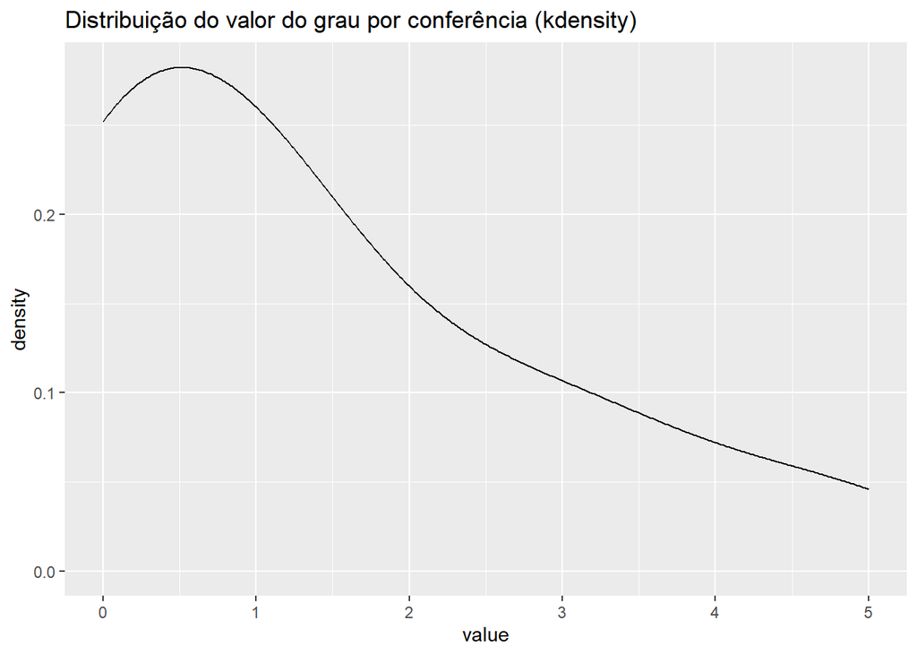

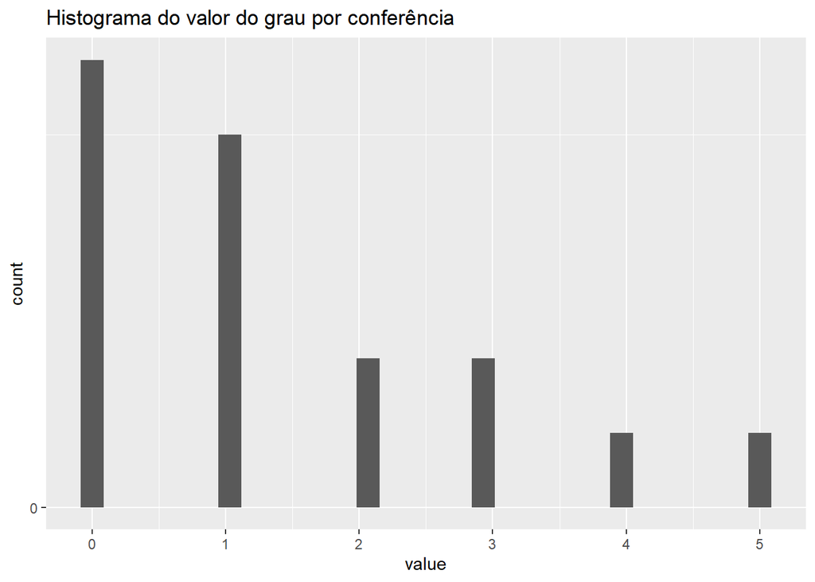

Estatísticas descritivas de grau - Rede Eventos (1970-1979)

| mean | sd | coef_var | median |
| --- | --- | --- | --- |
| 1.411765 | 1.543487 | 1.093303 | 1 |

Abaixo, as conferências com maior centralidade (grau simples)

Grau simples por conferências, top 10

| id | label | conference | tema | deg | deg_overavg | deg_overmedian |
| --- | --- | --- | --- | --- | --- | --- |
| 416 | UNCHE,Conf | UNCHE | Grandes conferências ONU | 5 | 3.5416667 | 5 |
| 478 | IOC,A10 | UNESCO IOC | Oceano | 4 | 2.8333333 | 4 |
| 111 | COFO,04 | FAO Committee on Forestry | Florestas | 3 | 2.1250000 | 3 |
| 477 | IOC,A09 | UNESCO IOC | Oceano | 3 | 2.1250000 | 3 |
| 417 | UNCHE,PrepCom 1 | UNCHE | Grandes conferências ONU | 2 | 1.4166667 | 2 |
| 476 | IOC,A08 | UNESCO IOC | Oceano | 2 | 1.4166667 | 2 |
| 110 | COFO,03 | FAO Committee on Forestry | Florestas | 1 | 0.7083333 | 1 |
| 290 | LDC,01 | London Convention on the Prevention of Marine Pollution by Dumping of Wastes and Other Matter 1972 | Oceano | 1 | 0.7083333 | 1 |
| 431 | UNEP GC 02 | UNEP Governing Council | Governança ambiental | 1 | 0.7083333 | 1 |
| 432 | UNEP GC 03 | UNEP Governing Council | Governança ambiental | 1 | 0.7083333 | 1 |

### 3.3.2 Dados de topologia da rede

Estatísticas de topologia da rede

| Statistic | Value | Network | YearBegin | YearEnd |
| --- | --- | --- | --- | --- |
| NVertices | 17.0000000 | Eventos70 | 1970 | 1979 |
| NArestas | 12.0000000 | Eventos70 | 1970 | 1979 |
| ArestasporVertice | 0.7058824 | Eventos70 | 1970 | 1979 |
| GrauMed | 1.4117647 | Eventos70 | 1970 | 1979 |
| GrauMed_weighted | 1.7647059 | Eventos70 | 1970 | 1979 |
| PesoMedioAresta | 1.2500000 | Eventos70 | 1970 | 1979 |
| Average_path_length | 2.0270270 | Eventos70 | 1970 | 1979 |
| Average_path_length_weighted | 2.1081081 | Eventos70 | 1970 | 1979 |
| Diameter | 4.0000000 | Eventos70 | 1970 | 1979 |
| Diameter_weighted | 4.0000000 | Eventos70 | 1970 | 1979 |
| Densidade | 0.0882353 | Eventos70 | 1970 | 1979 |
| Transitivity | 0.3750000 | Eventos70 | 1970 | 1979 |
| Transitivity_weighted_mean | 0.6296296 | Eventos70 | 1970 | 1979 |
| Average_clustering_coef | 0.5888889 | Eventos70 | 1970 | 1979 |
| N_componentes_isolados | 8.0000000 | Eventos70 | 1970 | 1979 |
| Cobertura_maiorcomp | 0.5294118 | Eventos70 | 1970 | 1979 |
| N_clustersLouvain | 9.0000000 | Eventos70 | 1970 | 1979 |
| Modularidade_clustersLouvain | 0.4711111 | Eventos70 | 1970 | 1979 |
| Modularidade_temas | 0.2534722 | Eventos70 | 1970 | 1979 |
| Modularidade_conference | 0.2881944 | Eventos70 | 1970 | 1979 |
| Assortativity_Ano | -0.1157025 | Eventos70 | 1970 | 1979 |

### 3.3.3 Visualização

Layout usa o Fruchterman-Reingold com os parâmetros padrão do igraph

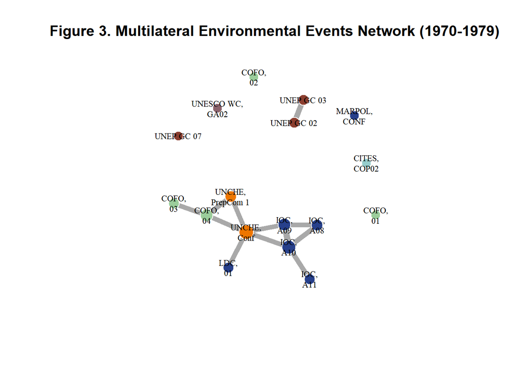

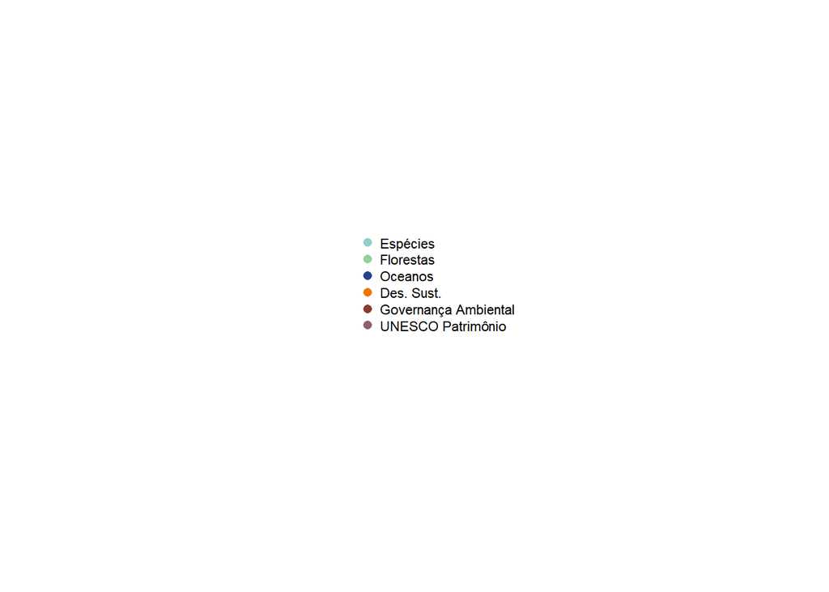

## 3.4 Década de 1980 (1980-1989)

```r
events80net <- yearfilter_net(full_eventNet, 1980, 1989)
```

### 3.4.1 Dados de centralidade

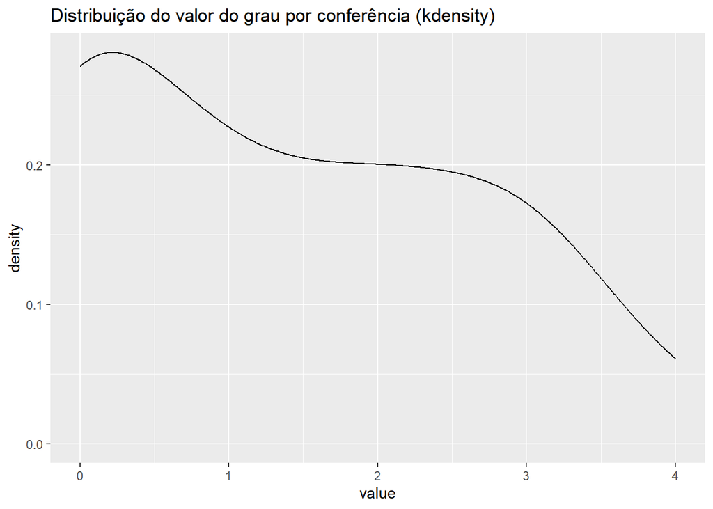

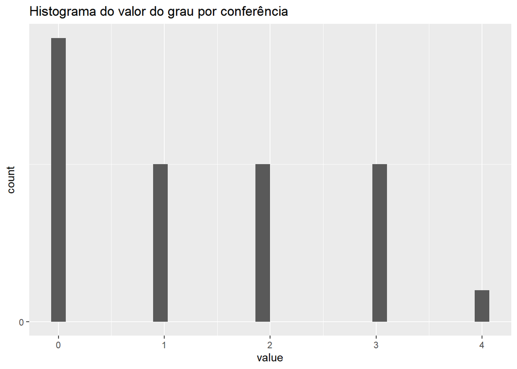

Estatísticas descritivas de grau - Rede Eventos (1980-1989)

| mean | sd | coef_var | median |
| --- | --- | --- | --- |
| 1.36 | 1.287116 | 0.9464086 | 1 |

Abaixo, as conferências com maior centralidade (grau simples)

Grau simples por conferências, top 10

| id | label | conference | tema | deg | deg_overavg | deg_overmedian |
| --- | --- | --- | --- | --- | --- | --- |
| 481 | IOC,A13 | UNESCO IOC | Oceano | 4 | 2.941177 | 4 |
| 82 | CITES,COP07 | Convention on International Trade in Endangered Species of Wild Fauna and Flora | Biodiversidade - Espécies | 3 | 2.205882 | 3 |
| 113 | COFO,06 | FAO Committee on Forestry | Florestas | 3 | 2.205882 | 3 |
| 115 | COFO,08 | FAO Committee on Forestry | Florestas | 3 | 2.205882 | 3 |
| 483 | IOC,A15 | UNESCO IOC | Oceano | 3 | 2.205882 | 3 |
| 506 | UNESCO WC,GA06 | UNESCO World Heritage Convention | Biodiversidade - UNESCO | 3 | 2.205882 | 3 |
| 15 | CBD,AHWG, 1 | Convention on Biological Diversity | Biodiversidade - CBD | 2 | 1.470588 | 2 |
| 114 | COFO,07 | FAO Committee on Forestry | Florestas | 2 | 1.470588 | 2 |
| 467 | UNEP GCSS,01 | UNEP Governing Council | Governança ambiental | 2 | 1.470588 | 2 |
| 480 | IOC,A12 | UNESCO IOC | Oceano | 2 | 1.470588 | 2 |

### 3.4.2 Dados de topologia da rede

Estatísticas de topologia da rede

| Statistic | Value | Network | YearBegin | YearEnd |
| --- | --- | --- | --- | --- |
| NVertices | 25.0000000 | Eventos80 | 1980 | 1989 |
| NArestas | 17.0000000 | Eventos80 | 1980 | 1989 |
| ArestasporVertice | 0.6800000 | Eventos80 | 1980 | 1989 |
| GrauMed | 1.3600000 | Eventos80 | 1980 | 1989 |
| GrauMed_weighted | 1.6000000 | Eventos80 | 1980 | 1989 |
| PesoMedioAresta | 1.1764706 | Eventos80 | 1980 | 1989 |
| Average_path_length | 1.7297297 | Eventos80 | 1980 | 1989 |
| Average_path_length_weighted | 2.0000000 | Eventos80 | 1980 | 1989 |
| Diameter | 3.0000000 | Eventos80 | 1980 | 1989 |
| Diameter_weighted | 4.0000000 | Eventos80 | 1980 | 1989 |
| Densidade | 0.0566667 | Eventos80 | 1980 | 1989 |
| Transitivity | 0.4615385 | Eventos80 | 1980 | 1989 |
| Transitivity_weighted_mean | 0.6325758 | Eventos80 | 1980 | 1989 |
| Average_clustering_coef | 0.6363636 | Eventos80 | 1980 | 1989 |
| N_componentes_isolados | 12.0000000 | Eventos80 | 1980 | 1989 |
| Cobertura_maiorcomp | 0.2800000 | Eventos80 | 1980 | 1989 |
| N_clustersLouvain | 13.0000000 | Eventos80 | 1980 | 1989 |
| Modularidade_clustersLouvain | 0.6662500 | Eventos80 | 1980 | 1989 |
| Modularidade_temas | 0.2993080 | Eventos80 | 1980 | 1989 |
| Modularidade_conference | 0.2993080 | Eventos80 | 1980 | 1989 |
| Assortativity_Ano | 0.2507870 | Eventos80 | 1980 | 1989 |

### 3.4.3 Visualização

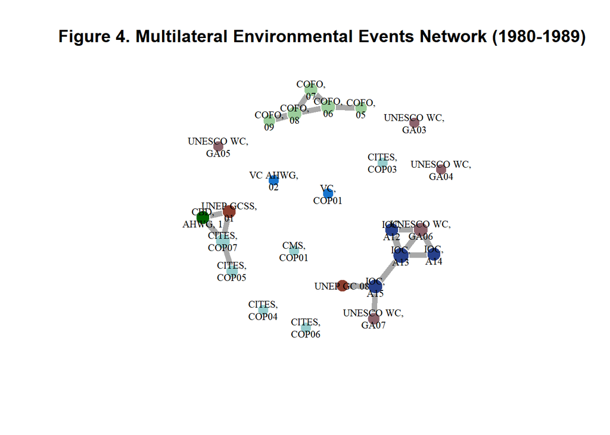

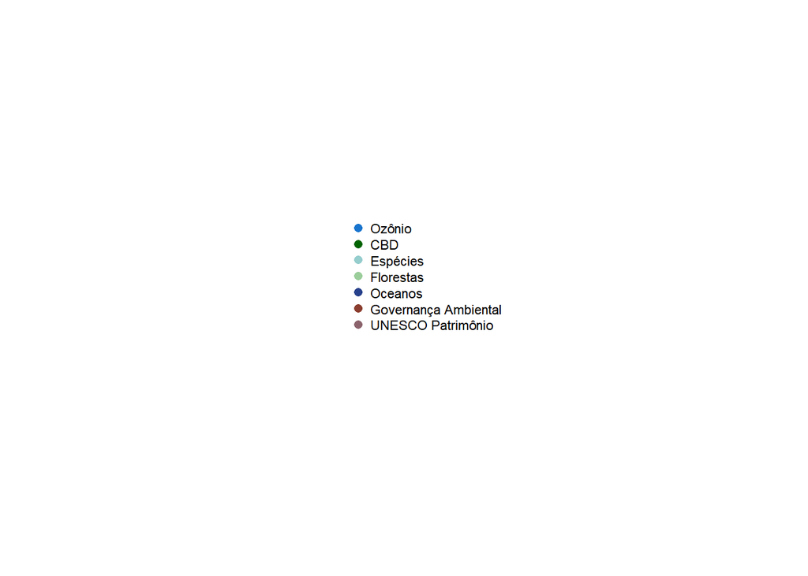

## 3.5 Década de 1990 (1990-1999)

Layout é F-R, mas altero parâmetros de repulsão pra deixar a figura mais visível.

```r
events90net <- yearfilter_net(full_eventNet, 1990, 1999)
```

### 3.5.1 Dados de centralidade

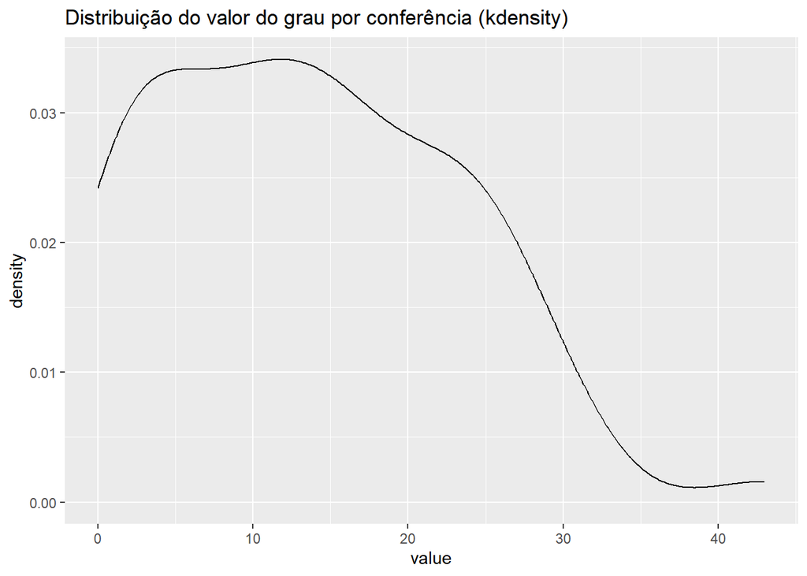

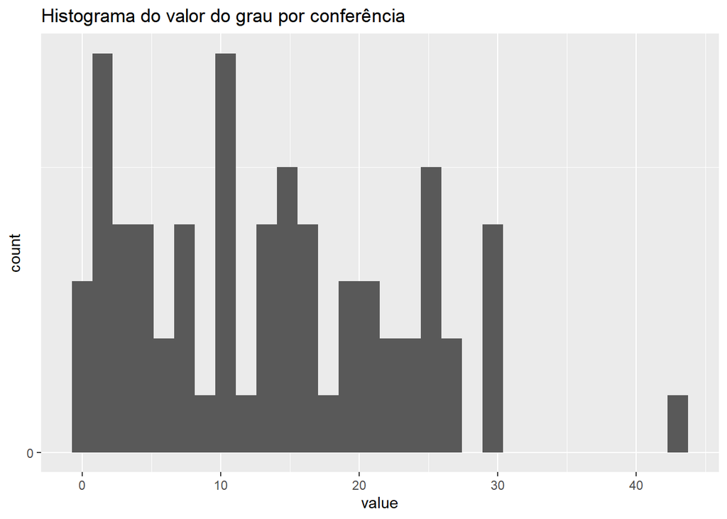

Estatísticas descritivas de grau - Rede Eventos (1990-1999)

| mean | sd | coef_var | median |
| --- | --- | --- | --- |
| 13.5942 | 9.590619 | 0.7054933 | 13 |

Abaixo, as conferências com maior centralidade (grau simples)

Grau simples por conferências, top 10

| id | label | conference | tema | deg | deg_overavg | deg_overmedian |
| --- | --- | --- | --- | --- | --- | --- |
| 411 | UNCED,Conf | UNCED | Grandes conferências ONU | 43 | 3.163113 | 3.307692 |
| 22 | CBD,COP01 | Convention on Biological Diversity | Biodiversidade - CBD | 30 | 2.206823 | 2.307692 |
| 560 | UNFCCC,INC09 | UNFCCC | Clima | 30 | 2.206823 | 2.307692 |
| 24 | CBD,COP03 | Convention on Biological Diversity | Biodiversidade - CBD | 29 | 2.133262 | 2.230769 |
| 561 | UNFCCC,INC10 | UNFCCC | Clima | 29 | 2.133262 | 2.230769 |
| 526 | UNFCCC,COP03 | UNFCCC | Clima | 26 | 1.912580 | 2.000000 |
| 552 | UNFCCC,INC02 | UNFCCC | Clima | 26 | 1.912580 | 2.000000 |
| 525 | UNFCCC,COP02 | UNFCCC | Clima | 25 | 1.839019 | 1.923077 |
| 527 | UNFCCC,COP04 | UNFCCC | Clima | 25 | 1.839019 | 1.923077 |
| 554 | UNFCCC,INC04 | UNFCCC | Clima | 25 | 1.839019 | 1.923077 |

### 3.5.2 Dados de topologia da rede

Estatísticas de topologia da rede

| Statistic | Value | Network | YearBegin | YearEnd |
| --- | --- | --- | --- | --- |
| NVertices | 69.0000000 | Eventos90 | 1990 | 1999 |
| NArestas | 469.0000000 | Eventos90 | 1990 | 1999 |
| ArestasporVertice | 6.7971014 | Eventos90 | 1990 | 1999 |
| GrauMed | 13.5942029 | Eventos90 | 1990 | 1999 |
| GrauMed_weighted | 24.0869565 | Eventos90 | 1990 | 1999 |
| PesoMedioAresta | 1.7718550 | Eventos90 | 1990 | 1999 |
| Average_path_length | 2.0317303 | Eventos90 | 1990 | 1999 |
| Average_path_length_weighted | 2.2940010 | Eventos90 | 1990 | 1999 |
| Diameter | 5.0000000 | Eventos90 | 1990 | 1999 |
| Diameter_weighted | 6.0000000 | Eventos90 | 1990 | 1999 |
| Densidade | 0.1999147 | Eventos90 | 1990 | 1999 |
| Transitivity | 0.5791455 | Eventos90 | 1990 | 1999 |
| Transitivity_weighted_mean | 0.6955824 | Eventos90 | 1990 | 1999 |
| Average_clustering_coef | 0.6433628 | Eventos90 | 1990 | 1999 |
| N_componentes_isolados | 5.0000000 | Eventos90 | 1990 | 1999 |
| Cobertura_maiorcomp | 0.9275362 | Eventos90 | 1990 | 1999 |
| N_clustersLouvain | 9.0000000 | Eventos90 | 1990 | 1999 |
| Modularidade_clustersLouvain | 0.3869977 | Eventos90 | 1990 | 1999 |
| Modularidade_temas | 0.2119353 | Eventos90 | 1990 | 1999 |
| Modularidade_conference | 0.1847646 | Eventos90 | 1990 | 1999 |
| Assortativity_Ano | 0.1767220 | Eventos90 | 1990 | 1999 |

### 3.5.3 Visualização

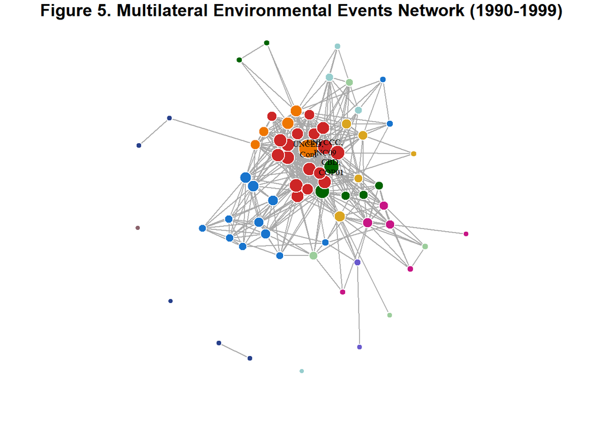

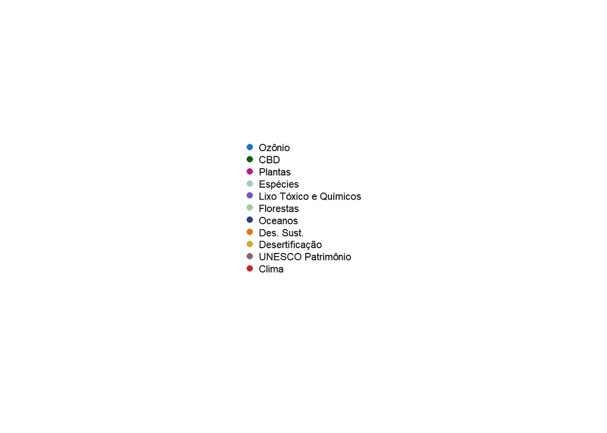

## 3.6 Década de 2000 (2000-2009)

Layout é F-R, mas altero parâmetros de repulsão pra deixar a figura mais visível.

```r
events00net <- yearfilter_net(full_eventNet, 2000, 2009)
```

### 3.6.1 Dados de centralidade

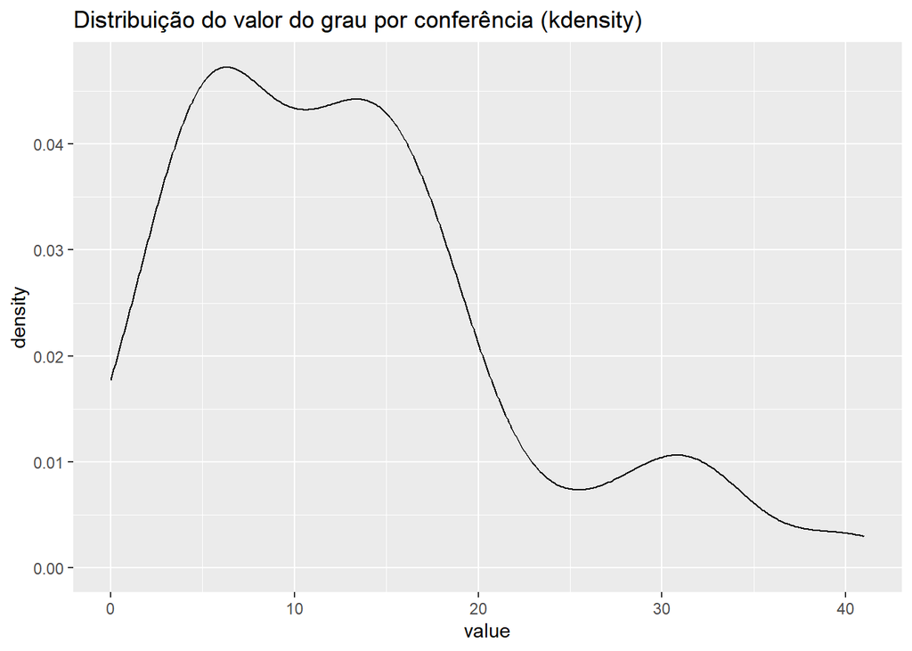

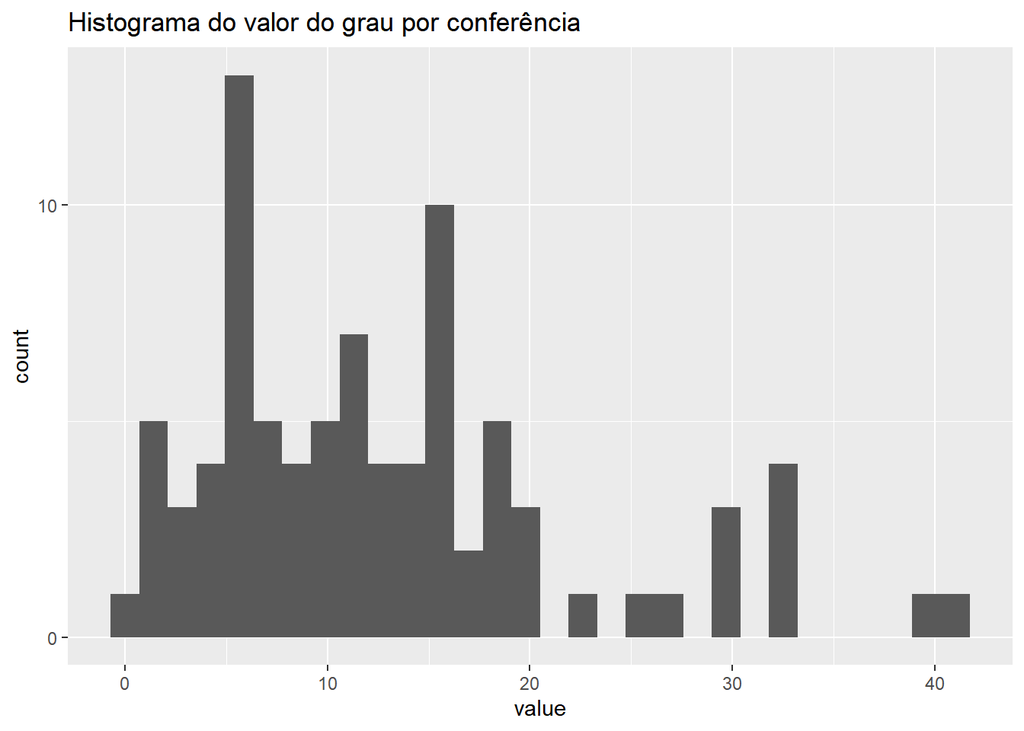

Estatísticas descritivas de grau - Rede Eventos (2000-2009)

| mean | sd | coef_var | median |
| --- | --- | --- | --- |
| 12.98851 | 9.125092 | 0.7025513 | 12 |

Abaixo, as conferências com maior centralidade (grau simples)

Grau simples por conferências, top 10

| id | label | conference | tema | deg | deg_overavg | deg_overmedian |
| --- | --- | --- | --- | --- | --- | --- |
| 539 | UNFCCC,COP15 | UNFCCC | Clima | 41 | 3.156637 | 3.416667 |
| 587 | WSSD,Conf | WSSD | Grandes conferências ONU | 39 | 3.002655 | 3.250000 |
| 536 | UNFCCC,COP12 | UNFCCC | Clima | 33 | 2.540708 | 2.750000 |
| 537 | UNFCCC,COP13 | UNFCCC | Clima | 33 | 2.540708 | 2.750000 |
| 30 | CBD,COP09 | Convention on Biological Diversity | Biodiversidade - CBD | 32 | 2.463717 | 2.666667 |
| 533 | UNFCCC,COP09 | UNFCCC | Clima | 32 | 2.463717 | 2.666667 |
| 29 | CBD,COP08 | Convention on Biological Diversity | Biodiversidade - CBD | 30 | 2.309734 | 2.500000 |
| 534 | UNFCCC,COP10 | UNFCCC | Clima | 30 | 2.309734 | 2.500000 |
| 538 | UNFCCC,COP14 | UNFCCC | Clima | 29 | 2.232743 | 2.416667 |
| 535 | UNFCCC,COP11 | UNFCCC | Clima | 27 | 2.078761 | 2.250000 |

### 3.6.2 Dados de topologia da rede

Estatísticas de topologia da rede

| Statistic | Value | Network | YearBegin | YearEnd |
| --- | --- | --- | --- | --- |
| NVertices | 87.0000000 | Eventos00 | 2000 | 2009 |
| NArestas | 565.0000000 | Eventos00 | 2000 | 2009 |
| ArestasporVertice | 6.4942529 | Eventos00 | 2000 | 2009 |
| GrauMed | 12.9885057 | Eventos00 | 2000 | 2009 |
| GrauMed_weighted | 57.6551724 | Eventos00 | 2000 | 2009 |
| PesoMedioAresta | 4.4389381 | Eventos00 | 2000 | 2009 |
| Average_path_length | 2.4424077 | Eventos00 | 2000 | 2009 |
| Average_path_length_weighted | 2.7575923 | Eventos00 | 2000 | 2009 |
| Diameter | 6.0000000 | Eventos00 | 2000 | 2009 |
| Diameter_weighted | 7.0000000 | Eventos00 | 2000 | 2009 |
| Densidade | 0.1510291 | Eventos00 | 2000 | 2009 |
| Transitivity | 0.5009658 | Eventos00 | 2000 | 2009 |
| Transitivity_weighted_mean | 0.6732824 | Eventos00 | 2000 | 2009 |
| Average_clustering_coef | 0.6195079 | Eventos00 | 2000 | 2009 |
| N_componentes_isolados | 2.0000000 | Eventos00 | 2000 | 2009 |
| Cobertura_maiorcomp | 0.9885057 | Eventos00 | 2000 | 2009 |
| N_clustersLouvain | 8.0000000 | Eventos00 | 2000 | 2009 |
| Modularidade_clustersLouvain | 0.2536672 | Eventos00 | 2000 | 2009 |
| Modularidade_temas | 0.2559245 | Eventos00 | 2000 | 2009 |
| Modularidade_conference | 0.1989913 | Eventos00 | 2000 | 2009 |
| Assortativity_Ano | 0.2616316 | Eventos00 | 2000 | 2009 |

### 3.6.3 Visualização

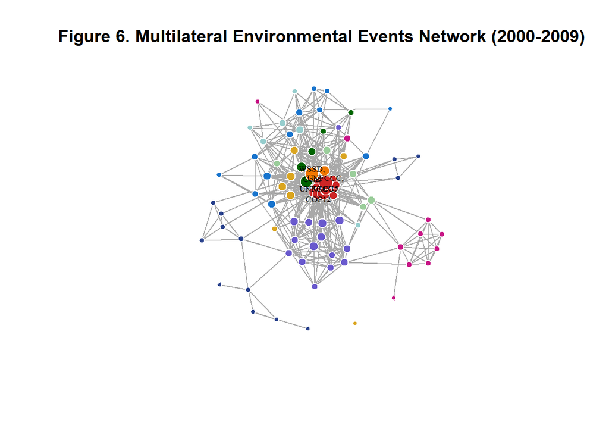

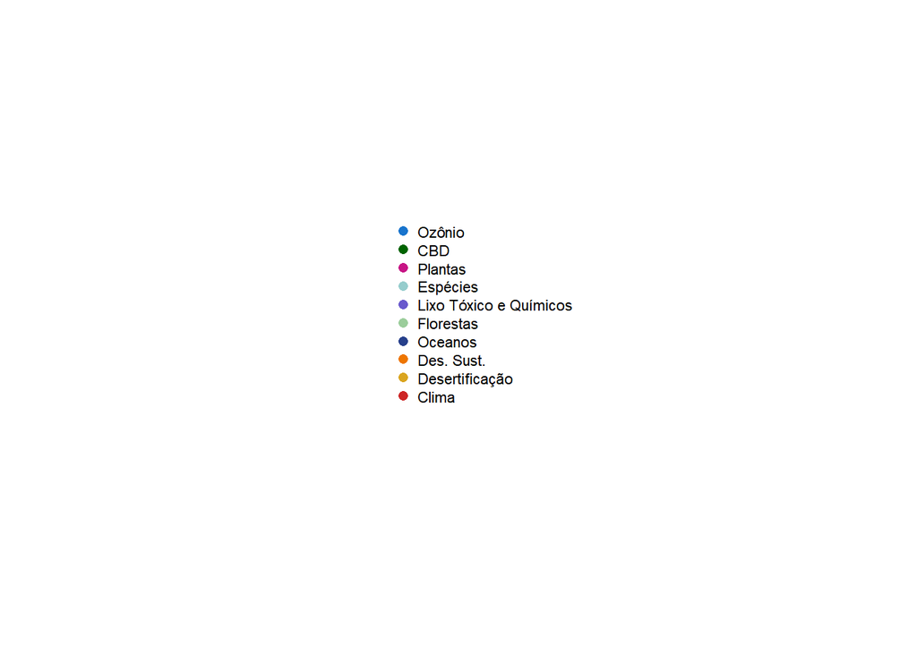

### 3.6.4 Década de 2010 (2010-2018)

Layout é F-R, mas altero parâmetros de repulsão pra deixar a figura mais visível.

```r
events10net <- yearfilter_net(full_eventNet, 2010, 2018)
```

### 3.6.5 Dados de centralidade

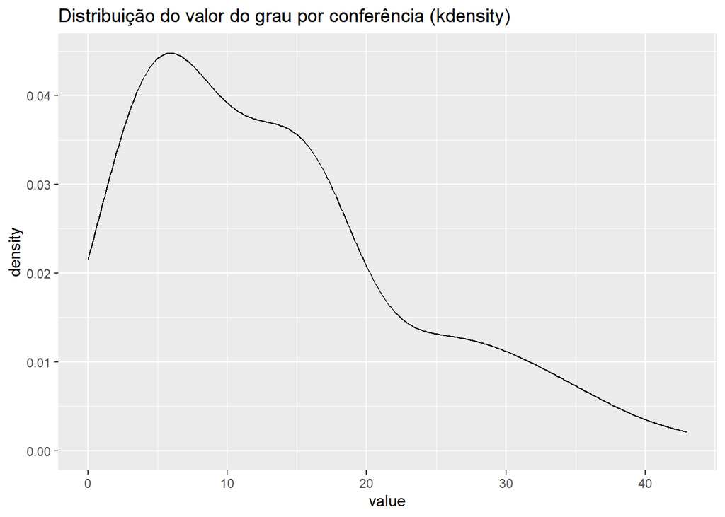

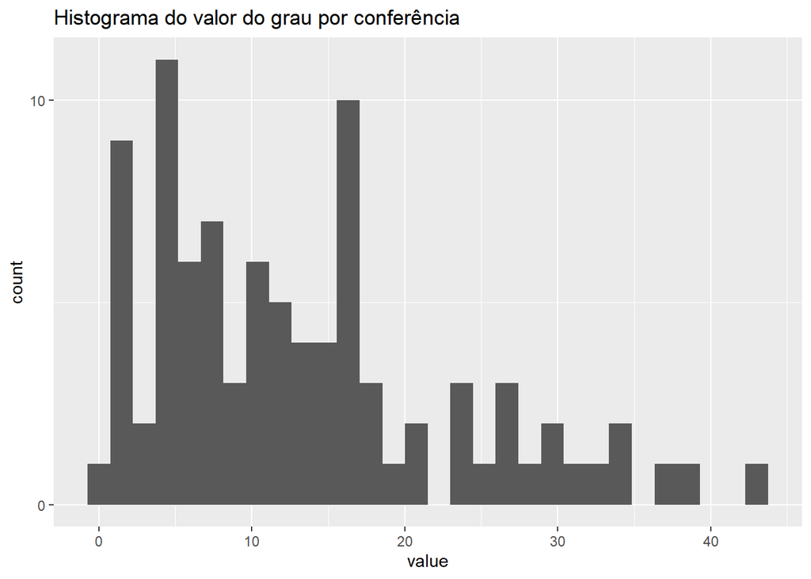

Estatísticas descritivas de grau - Rede eventos (2010-2018)

| mean | sd | coef_var | median |
| --- | --- | --- | --- |
| 13.36264 | 9.886598 | 0.7398687 | 12 |

Abaixo, as conferências com maior centralidade (grau simples)

Grau simples por conferências, top 10

| id | label | conference | tema | deg | deg_overavg | deg_overmedian |
| --- | --- | --- | --- | --- | --- | --- |
| 421 | UNCSD,Conf | UNCSD | Grandes conferências ONU | 43 | 3.217928 | 3.583333 |
| 545 | UNFCCC,COP21 | UNFCCC | Clima | 38 | 2.843750 | 3.166667 |
| 547 | UNFCCC,COP23 | UNFCCC | Clima | 37 | 2.768915 | 3.083333 |
| 544 | UNFCCC,COP20 | UNFCCC | Clima | 34 | 2.544408 | 2.833333 |
| 546 | UNFCCC,COP22 | UNFCCC | Clima | 34 | 2.544408 | 2.833333 |
| 543 | UNFCCC,COP19 | UNFCCC | Clima | 32 | 2.394737 | 2.666667 |
| 548 | UNFCCC,COP24 | UNFCCC | Clima | 31 | 2.319901 | 2.583333 |
| 31 | CBD,COP10 | Convention on Biological Diversity | Biodiversidade - CBD | 30 | 2.245066 | 2.500000 |
| 34 | CBD,COP13 | Convention on Biological Diversity | Biodiversidade - CBD | 30 | 2.245066 | 2.500000 |
| 32 | CBD,COP11 | Convention on Biological Diversity | Biodiversidade - CBD | 28 | 2.095395 | 2.333333 |

### 3.6.6 Dados de topologia da rede

Estatísticas de topologia da rede

| Statistic | Value | Network | YearBegin | YearEnd |
| --- | --- | --- | --- | --- |
| NVertices | 91.0000000 | Eventos10 | 2010 | 2018 |
| NArestas | 608.0000000 | Eventos10 | 2010 | 2018 |
| ArestasporVertice | 6.6813187 | Eventos10 | 2010 | 2018 |
| GrauMed | 13.3626374 | Eventos10 | 2010 | 2018 |
| GrauMed_weighted | 57.8241758 | Eventos10 | 2010 | 2018 |
| PesoMedioAresta | 4.3273026 | Eventos10 | 2010 | 2018 |
| Average_path_length | 2.3276869 | Eventos10 | 2010 | 2018 |
| Average_path_length_weighted | 2.6217874 | Eventos10 | 2010 | 2018 |
| Diameter | 5.0000000 | Eventos10 | 2010 | 2018 |
| Diameter_weighted | 6.0000000 | Eventos10 | 2010 | 2018 |
| Densidade | 0.1484737 | Eventos10 | 2010 | 2018 |
| Transitivity | 0.5393202 | Eventos10 | 2010 | 2018 |
| Transitivity_weighted_mean | 0.7286044 | Eventos10 | 2010 | 2018 |
| Average_clustering_coef | 0.6718500 | Eventos10 | 2010 | 2018 |
| N_componentes_isolados | 3.0000000 | Eventos10 | 2010 | 2018 |
| Cobertura_maiorcomp | 0.9120879 | Eventos10 | 2010 | 2018 |
| N_clustersLouvain | 8.0000000 | Eventos10 | 2010 | 2018 |
| Modularidade_clustersLouvain | 0.2948974 | Eventos10 | 2010 | 2018 |
| Modularidade_temas | 0.2571254 | Eventos10 | 2010 | 2018 |
| Modularidade_conference | 0.1877678 | Eventos10 | 2010 | 2018 |
| Assortativity_Ano | 0.1739981 | Eventos10 | 2010 | 2018 |

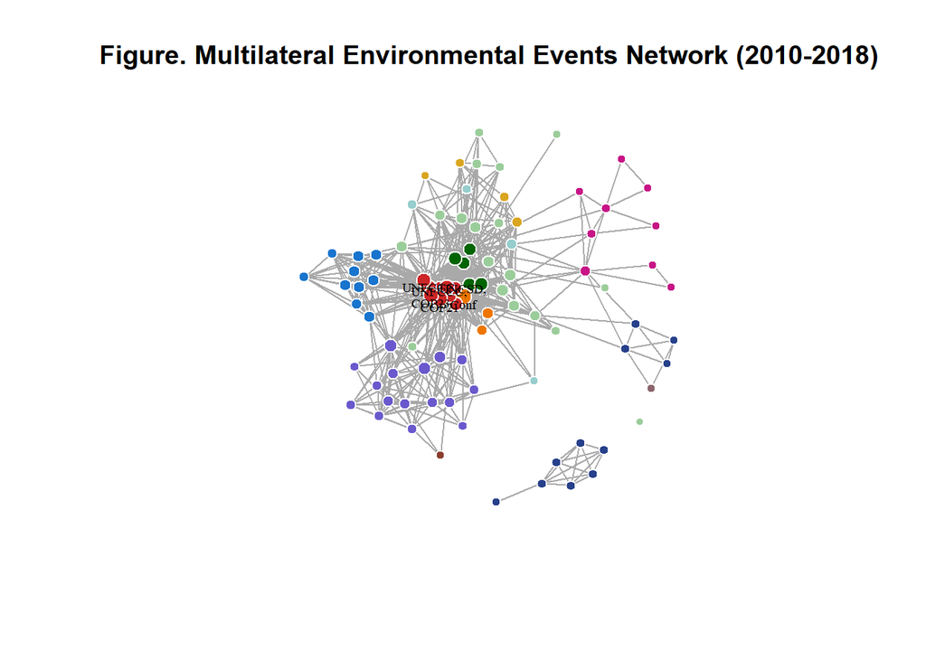

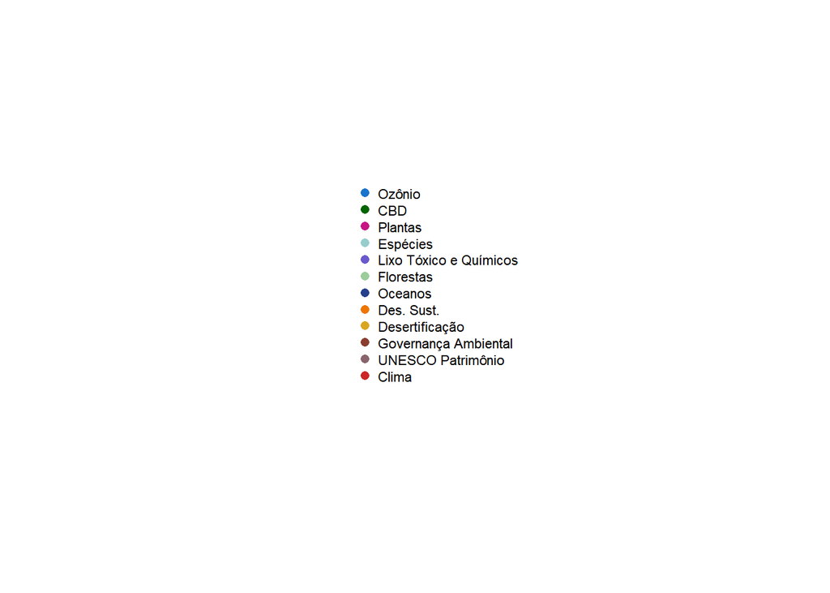

## 3.7 Comparação da topologia das redes

| Statistic | Value | Network | YearBegin | YearEnd |
| --- | --- | --- | --- | --- |
| NVertices | 30 | SimplesConf | 1970 | 2018 |
| NVertices | 289 | EventosTotal | 1970 | 2018 |
| NVertices | 17 | Eventos70 | 1970 | 1979 |
| NVertices | 25 | Eventos80 | 1980 | 1989 |
| NVertices | 69 | Eventos90 | 1990 | 1999 |
| NVertices | 87 | Eventos00 | 2000 | 2009 |
| NVertices | 91 | Eventos10 | 2010 | 2018 |

| Statistic | Value | Network | YearBegin | YearEnd |
| --- | --- | --- | --- | --- |
| NArestas | 191 | SimplesConf | 1970 | 2018 |
| NArestas | 3497 | EventosTotal | 1970 | 2018 |
| NArestas | 12 | Eventos70 | 1970 | 1979 |
| NArestas | 17 | Eventos80 | 1980 | 1989 |
| NArestas | 469 | Eventos90 | 1990 | 1999 |
| NArestas | 565 | Eventos00 | 2000 | 2009 |
| NArestas | 608 | Eventos10 | 2010 | 2018 |

| Statistic | Value | Network | YearBegin | YearEnd |
| --- | --- | --- | --- | --- |
| ArestasporVertice | 6.3666667 | SimplesConf | 1970 | 2018 |
| ArestasporVertice | 12.1003460 | EventosTotal | 1970 | 2018 |
| ArestasporVertice | 0.7058824 | Eventos70 | 1970 | 1979 |
| ArestasporVertice | 0.6800000 | Eventos80 | 1980 | 1989 |
| ArestasporVertice | 6.7971014 | Eventos90 | 1990 | 1999 |
| ArestasporVertice | 6.4942529 | Eventos00 | 2000 | 2009 |
| ArestasporVertice | 6.6813187 | Eventos10 | 2010 | 2018 |

| Statistic | Value | Network | YearBegin | YearEnd |
| --- | --- | --- | --- | --- |
| GrauMed | 12.733333 | SimplesConf | 1970 | 2018 |
| GrauMed | 24.200692 | EventosTotal | 1970 | 2018 |
| GrauMed | 1.411765 | Eventos70 | 1970 | 1979 |
| GrauMed | 1.360000 | Eventos80 | 1980 | 1989 |
| GrauMed | 13.594203 | Eventos90 | 1990 | 1999 |
| GrauMed | 12.988506 | Eventos00 | 2000 | 2009 |
| GrauMed | 13.362637 | Eventos10 | 2010 | 2018 |

| Statistic | Value | Network | YearBegin | YearEnd |
| --- | --- | --- | --- | --- |
| GrauMed_weighted | 285.800000 | SimplesConf | 1970 | 2018 |
| GrauMed_weighted | 73.453287 | EventosTotal | 1970 | 2018 |
| GrauMed_weighted | 1.764706 | Eventos70 | 1970 | 1979 |
| GrauMed_weighted | 1.600000 | Eventos80 | 1980 | 1989 |
| GrauMed_weighted | 24.086956 | Eventos90 | 1990 | 1999 |
| GrauMed_weighted | 57.655172 | Eventos00 | 2000 | 2009 |
| GrauMed_weighted | 57.824176 | Eventos10 | 2010 | 2018 |

| Statistic | Value | Network | YearBegin | YearEnd |
| --- | --- | --- | --- | --- |
| PesoMedioAresta | 22.445026 | SimplesConf | 1970 | 2018 |
| PesoMedioAresta | 3.035173 | EventosTotal | 1970 | 2018 |
| PesoMedioAresta | 1.250000 | Eventos70 | 1970 | 1979 |
| PesoMedioAresta | 1.176471 | Eventos80 | 1980 | 1989 |
| PesoMedioAresta | 1.771855 | Eventos90 | 1990 | 1999 |
| PesoMedioAresta | 4.438938 | Eventos00 | 2000 | 2009 |
| PesoMedioAresta | 4.327303 | Eventos10 | 2010 | 2018 |

| Statistic | Value | Network | YearBegin | YearEnd |
| --- | --- | --- | --- | --- |
| Average_path_length | 1.629885 | SimplesConf | 1970 | 2018 |
| Average_path_length | 2.502125 | EventosTotal | 1970 | 2018 |
| Average_path_length | 2.027027 | Eventos70 | 1970 | 1979 |
| Average_path_length | 1.729730 | Eventos80 | 1980 | 1989 |
| Average_path_length | 2.031730 | Eventos90 | 1990 | 1999 |
| Average_path_length | 2.442408 | Eventos00 | 2000 | 2009 |
| Average_path_length | 2.327687 | Eventos10 | 2010 | 2018 |

| Statistic | Value | Network | YearBegin | YearEnd |
| --- | --- | --- | --- | --- |
| Average_path_length_weighted | 4.073563 | SimplesConf | 1970 | 2018 |
| Average_path_length_weighted | 2.698259 | EventosTotal | 1970 | 2018 |
| Average_path_length_weighted | 2.108108 | Eventos70 | 1970 | 1979 |
| Average_path_length_weighted | 2.000000 | Eventos80 | 1980 | 1989 |
| Average_path_length_weighted | 2.294001 | Eventos90 | 1990 | 1999 |
| Average_path_length_weighted | 2.757592 | Eventos00 | 2000 | 2009 |
| Average_path_length_weighted | 2.621787 | Eventos10 | 2010 | 2018 |

| Statistic | Value | Network | YearBegin | YearEnd |
| --- | --- | --- | --- | --- |
| Diameter | 4 | SimplesConf | 1970 | 2018 |
| Diameter | 8 | EventosTotal | 1970 | 2018 |
| Diameter | 4 | Eventos70 | 1970 | 1979 |
| Diameter | 3 | Eventos80 | 1980 | 1989 |
| Diameter | 5 | Eventos90 | 1990 | 1999 |
| Diameter | 6 | Eventos00 | 2000 | 2009 |
| Diameter | 5 | Eventos10 | 2010 | 2018 |

| Statistic | Value | Network | YearBegin | YearEnd |
| --- | --- | --- | --- | --- |
| Diameter_weighted | 10 | SimplesConf | 1970 | 2018 |
| Diameter_weighted | 11 | EventosTotal | 1970 | 2018 |
| Diameter_weighted | 4 | Eventos70 | 1970 | 1979 |
| Diameter_weighted | 4 | Eventos80 | 1980 | 1989 |
| Diameter_weighted | 6 | Eventos90 | 1990 | 1999 |
| Diameter_weighted | 7 | Eventos00 | 2000 | 2009 |
| Diameter_weighted | 6 | Eventos10 | 2010 | 2018 |

| Statistic | Value | Network | YearBegin | YearEnd |
| --- | --- | --- | --- | --- |
| Densidade | 0.4390805 | SimplesConf | 1970 | 2018 |
| Densidade | 0.0840302 | EventosTotal | 1970 | 2018 |
| Densidade | 0.0882353 | Eventos70 | 1970 | 1979 |
| Densidade | 0.0566667 | Eventos80 | 1980 | 1989 |
| Densidade | 0.1999147 | Eventos90 | 1990 | 1999 |
| Densidade | 0.1510291 | Eventos00 | 2000 | 2009 |
| Densidade | 0.1484737 | Eventos10 | 2010 | 2018 |

| Statistic | Value | Network | YearBegin | YearEnd |
| --- | --- | --- | --- | --- |
| Transitivity | 0.7147208 | SimplesConf | 1970 | 2018 |
| Transitivity | 0.4699422 | EventosTotal | 1970 | 2018 |
| Transitivity | 0.3750000 | Eventos70 | 1970 | 1979 |
| Transitivity | 0.4615385 | Eventos80 | 1980 | 1989 |
| Transitivity | 0.5791455 | Eventos90 | 1990 | 1999 |
| Transitivity | 0.5009658 | Eventos00 | 2000 | 2009 |
| Transitivity | 0.5393202 | Eventos10 | 2010 | 2018 |

| Statistic | Value | Network | YearBegin | YearEnd |
| --- | --- | --- | --- | --- |
| Transitivity_weighted_mean | 0.8965983 | SimplesConf | 1970 | 2018 |
| Transitivity_weighted_mean | 0.6582526 | EventosTotal | 1970 | 2018 |
| Transitivity_weighted_mean | 0.6296296 | Eventos70 | 1970 | 1979 |
| Transitivity_weighted_mean | 0.6325758 | Eventos80 | 1980 | 1989 |
| Transitivity_weighted_mean | 0.6955824 | Eventos90 | 1990 | 1999 |
| Transitivity_weighted_mean | 0.6732824 | Eventos00 | 2000 | 2009 |
| Transitivity_weighted_mean | 0.7286044 | Eventos10 | 2010 | 2018 |

| Statistic | Value | Network | YearBegin | YearEnd |
| --- | --- | --- | --- | --- |
| Average_clustering_coef | 0.7999237 | SimplesConf | 1970 | 2018 |
| Average_clustering_coef | 0.6096176 | EventosTotal | 1970 | 2018 |
| Average_clustering_coef | 0.5888889 | Eventos70 | 1970 | 1979 |
| Average_clustering_coef | 0.6363636 | Eventos80 | 1980 | 1989 |
| Average_clustering_coef | 0.6433628 | Eventos90 | 1990 | 1999 |
| Average_clustering_coef | 0.6195079 | Eventos00 | 2000 | 2009 |
| Average_clustering_coef | 0.6718500 | Eventos10 | 2010 | 2018 |

| Statistic | Value | Network | YearBegin | YearEnd |
| --- | --- | --- | --- | --- |
| N_componentes_isolados | 1 | SimplesConf | 1970 | 2018 |
| N_componentes_isolados | 10 | EventosTotal | 1970 | 2018 |
| N_componentes_isolados | 8 | Eventos70 | 1970 | 1979 |
| N_componentes_isolados | 12 | Eventos80 | 1980 | 1989 |
| N_componentes_isolados | 5 | Eventos90 | 1990 | 1999 |
| N_componentes_isolados | 2 | Eventos00 | 2000 | 2009 |
| N_componentes_isolados | 3 | Eventos10 | 2010 | 2018 |

| Statistic | Value | Network | YearBegin | YearEnd |
| --- | --- | --- | --- | --- |
| Cobertura_maiorcomp | 1.0000000 | SimplesConf | 1970 | 2018 |
| Cobertura_maiorcomp | 0.9688581 | EventosTotal | 1970 | 2018 |
| Cobertura_maiorcomp | 0.5294118 | Eventos70 | 1970 | 1979 |
| Cobertura_maiorcomp | 0.2800000 | Eventos80 | 1980 | 1989 |
| Cobertura_maiorcomp | 0.9275362 | Eventos90 | 1990 | 1999 |
| Cobertura_maiorcomp | 0.9885057 | Eventos00 | 2000 | 2009 |
| Cobertura_maiorcomp | 0.9120879 | Eventos10 | 2010 | 2018 |

| Statistic | Value | Network | YearBegin | YearEnd |
| --- | --- | --- | --- | --- |
| N_clustersLouvain | 4 | SimplesConf | 1970 | 2018 |
| N_clustersLouvain | 17 | EventosTotal | 1970 | 2018 |
| N_clustersLouvain | 9 | Eventos70 | 1970 | 1979 |
| N_clustersLouvain | 13 | Eventos80 | 1980 | 1989 |
| N_clustersLouvain | 9 | Eventos90 | 1990 | 1999 |
| N_clustersLouvain | 8 | Eventos00 | 2000 | 2009 |
| N_clustersLouvain | 8 | Eventos10 | 2010 | 2018 |

| Statistic | Value | Network | YearBegin | YearEnd |
| --- | --- | --- | --- | --- |
| Modularidade_clustersLouvain | 0.1193490 | SimplesConf | 1970 | 2018 |
| Modularidade_clustersLouvain | 0.3170864 | EventosTotal | 1970 | 2018 |
| Modularidade_clustersLouvain | 0.4711111 | Eventos70 | 1970 | 1979 |
| Modularidade_clustersLouvain | 0.6662500 | Eventos80 | 1980 | 1989 |
| Modularidade_clustersLouvain | 0.3869977 | Eventos90 | 1990 | 1999 |
| Modularidade_clustersLouvain | 0.2536672 | Eventos00 | 2000 | 2009 |
| Modularidade_clustersLouvain | 0.2948974 | Eventos10 | 2010 | 2018 |

| Statistic | Value | Network | YearBegin | YearEnd |
| --- | --- | --- | --- | --- |
| Modularidade_temas | 0.0263288 | SimplesConf | 1970 | 2018 |
| Modularidade_temas | 0.2594532 | EventosTotal | 1970 | 2018 |
| Modularidade_temas | 0.2534722 | Eventos70 | 1970 | 1979 |
| Modularidade_temas | 0.2993080 | Eventos80 | 1980 | 1989 |
| Modularidade_temas | 0.2119353 | Eventos90 | 1990 | 1999 |
| Modularidade_temas | 0.2559245 | Eventos00 | 2000 | 2009 |
| Modularidade_temas | 0.2571254 | Eventos10 | 2010 | 2018 |

| Statistic | Value | Network | YearBegin | YearEnd |
| --- | --- | --- | --- | --- |
| Modularidade_conference | -0.0431183 | SimplesConf | 1970 | 2018 |
| Modularidade_conference | 0.2083641 | EventosTotal | 1970 | 2018 |
| Modularidade_conference | 0.2881944 | Eventos70 | 1970 | 1979 |
| Modularidade_conference | 0.2993080 | Eventos80 | 1980 | 1989 |
| Modularidade_conference | 0.1847646 | Eventos90 | 1990 | 1999 |
| Modularidade_conference | 0.1989913 | Eventos00 | 2000 | 2009 |
| Modularidade_conference | 0.1877678 | Eventos10 | 2010 | 2018 |

| Statistic | Value | Network | YearBegin | YearEnd |
| --- | --- | --- | --- | --- |
| Assortativity_Ano | 0.0913559 | SimplesConf | 1970 | 2018 |
| Assortativity_Ano | 0.5381472 | EventosTotal | 1970 | 2018 |
| Assortativity_Ano | -0.1157025 | Eventos70 | 1970 | 1979 |
| Assortativity_Ano | 0.2507870 | Eventos80 | 1980 | 1989 |
| Assortativity_Ano | 0.1767220 | Eventos90 | 1990 | 1999 |
| Assortativity_Ano | 0.2616316 | Eventos00 | 2000 | 2009 |
| Assortativity_Ano | 0.1739981 | Eventos10 | 2010 | 2018 |

## 3.8 Rede em janela de 2 anos

Aqui a ideia era apresentar evolução das estatísticas ao longo do tempo, usando redes com janelas de N anos.

### 3.8.1 Medidas do tamanho da rede

Aqui estou usando janelas de 3 anos (i.e., p/ 1972, incluímos 1970, 1971 e 1972). Na função, o parâmetro de tamanho da janela é 2.

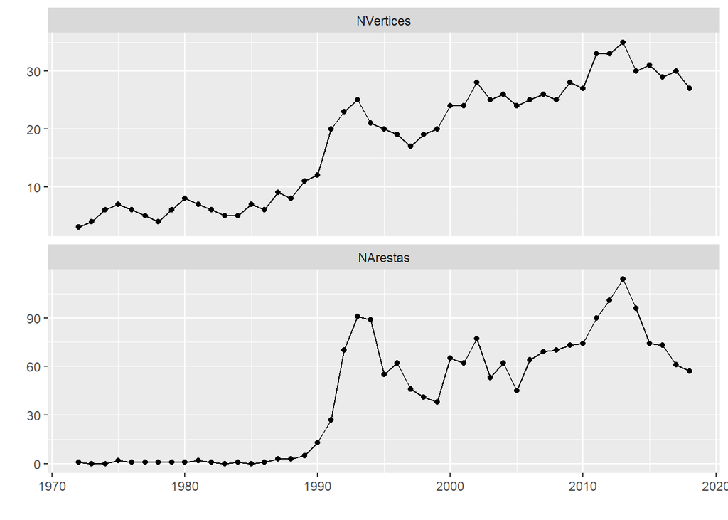

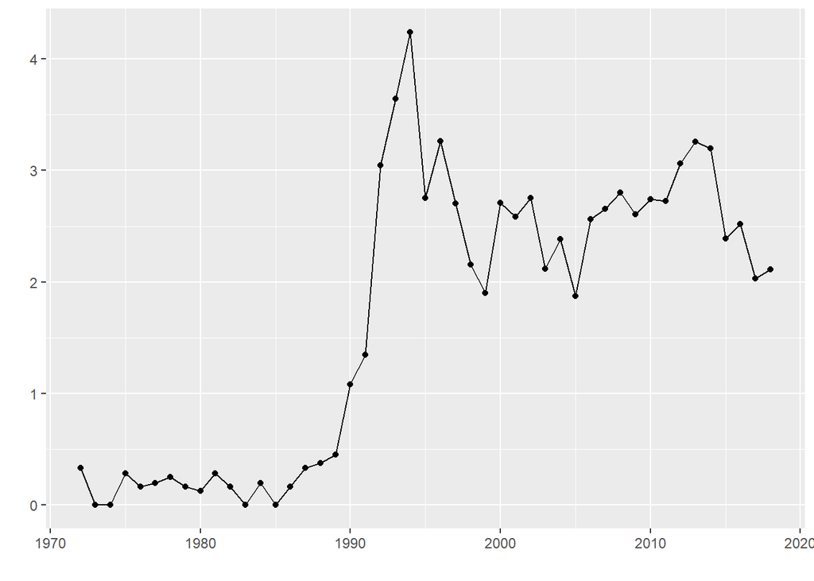

```r
full_df %>% filter(Statistic == "ArestasporVertice") %>%
  ggplot(aes(x = ano, y = Value)) + geom_point() +
  geom_line() +  ylab("") + xlab("")
```

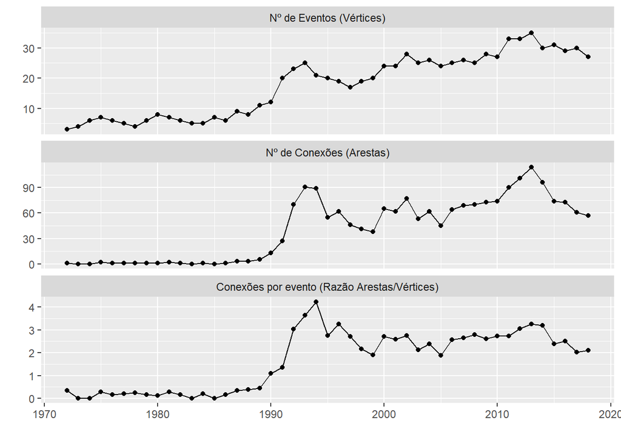

```r
full_df %>% filter(Statistic %in% c("NVertices", "NArestas", "ArestasporVertice")) %>%
  mutate(Statistic = case_when( Statistic == "NVertices" ~ "Nº de Eventos (Vértices)",
                                Statistic == "NArestas" ~ "Nº de Conexões (Arestas)",
                                Statistic == "ArestasporVertice" ~ "Conexões por evento (Razão Arestas/Vértices)"
                                )) %>%

  ggplot(aes(x = ano, y = Value)) + geom_point() +
  geom_line() + facet_wrap(~fct_rev(Statistic), ncol = 1, scales = "free_y") +
  ylab("") + xlab("")
```

### 3.8.2 Medidas da fragmentação da rede

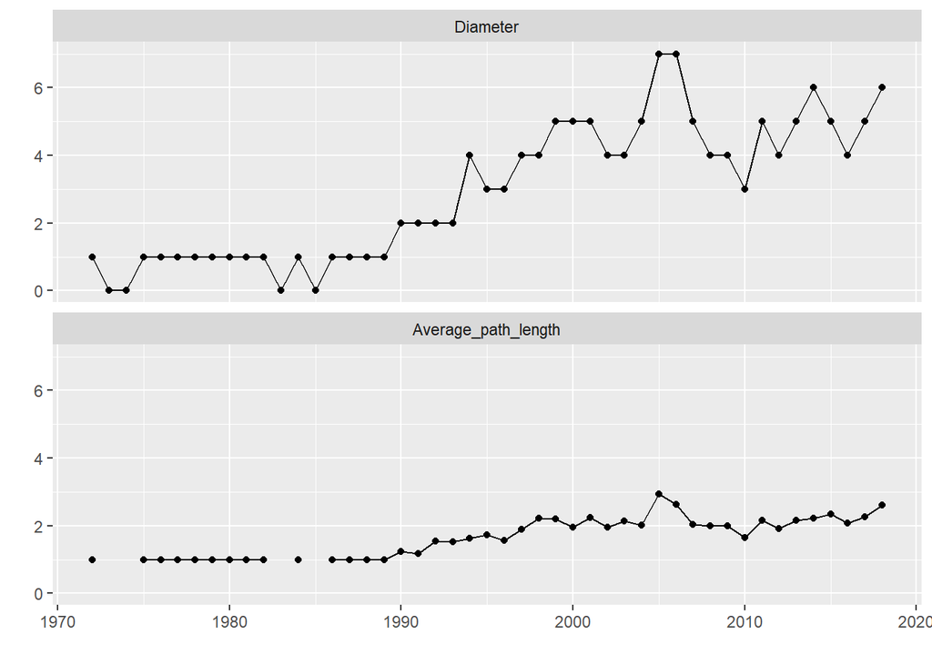

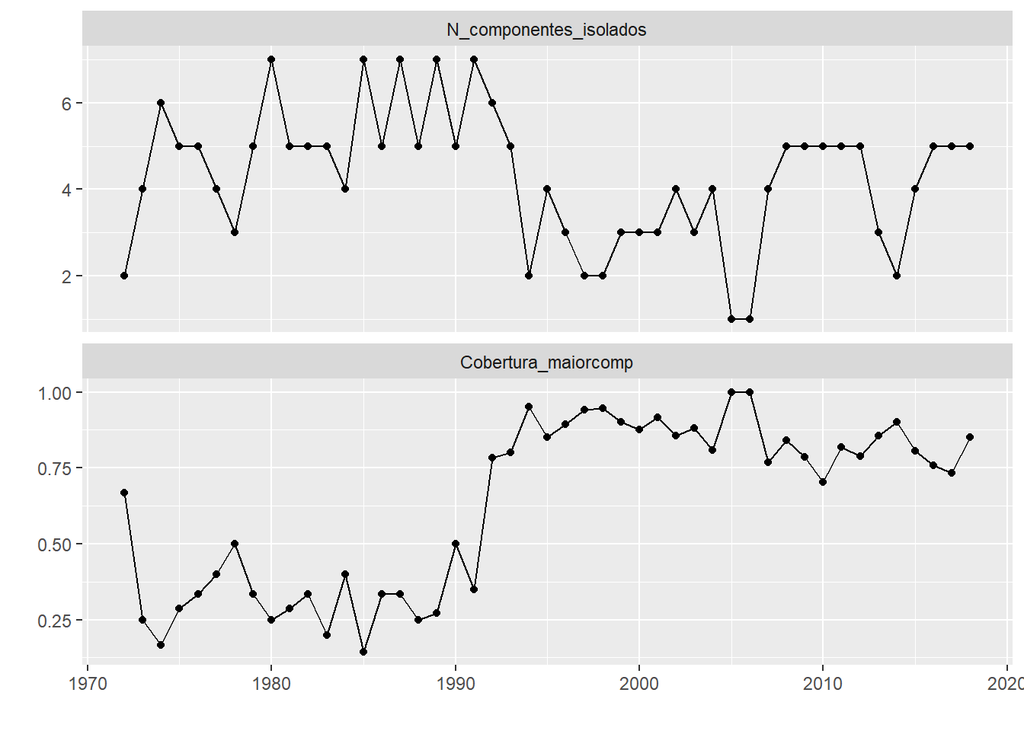

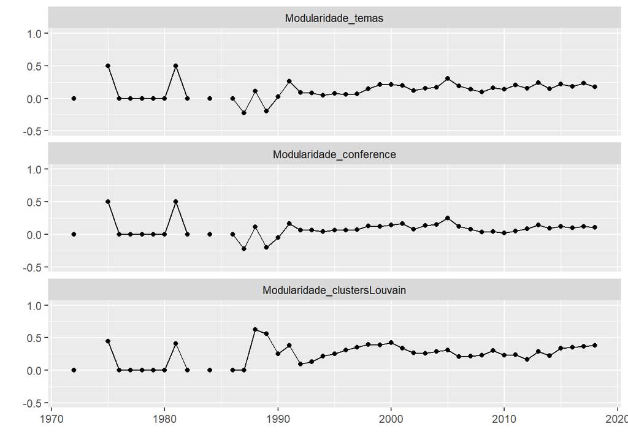

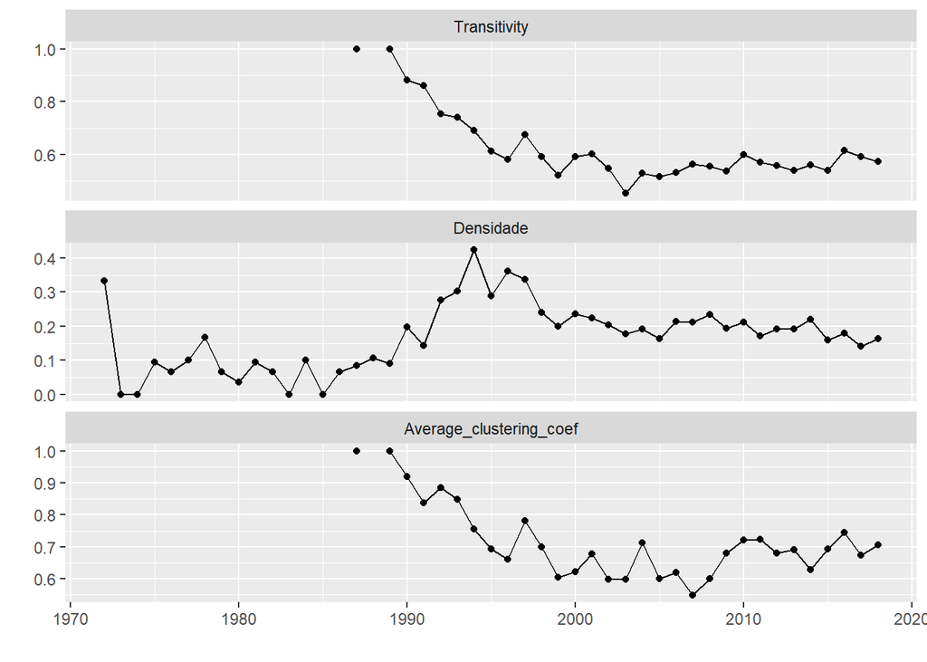